# Using the fretr Package to Draw Guitar Fretboards

This vignette will run a few examples of the high-level fretboard map functions in the fretr package, plus give you some example code (that is **not** run) to show you how to generate sets of fretboard maps saved to a *.pdf file.

To understand how the lower-level functions work, examine the source code of these high-level functions:

- `chordShapePlots()`
- `scalePositionPlots()`
- `parallelModePlots()`

```r
library(fretr)
```

## chordShapePlots()

Chord shape plots show the locations of the CAGED chord shapes for a given root note. Both the major and minor shapes are shown, as well as the notes of the corresponding major and minor scales.

Here is an example of how to set up a graphics device to plot to:

```r
# plot to the default device (not run by the vignette)
dev.new(noRStudioGD = TRUE, width=8.5, height=11)
```

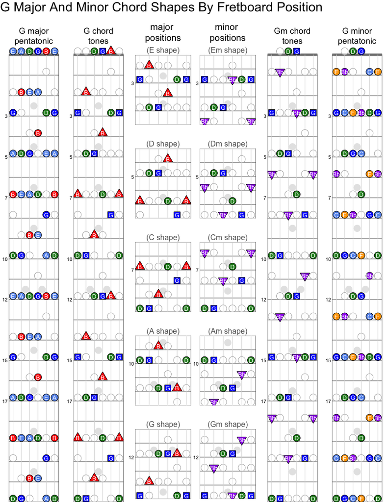

```r
# Generate fretboard maps of major and minor chords in the key of G
chordShapePlots("G", in.context=T, pdffile=NA, seven=FALSE)
```

Here is some code (**not** run) that will generate a set of these fretboard maps in a single *.pdf file, including the 7ths of each chord:

```r
out.dir <- file.path(getwd(), "fretr_output")
if(!dir.exists(out.dir)) dir.create(out.dir)

# generate major/minor chord shape plots for each root in a single file
seven <- TRUE
pdffile <- file.path(out.dir,
   paste0("maj", ifelse(seven,"7-min7", "or-minor"), " chord shapes.pdf"))
pdf(file=pdffile,  width=8.5, height=11, paper="a4", onefile=TRUE)
for(key in c("F","C","G","D","A","E","B","F#","Db","Ab","Eb","Bb")){
   chordShapePlots(key, in.context=T, pdffile=NA, seven=seven)
}
dev.off()
```

## scalePositionPlots()

Scale position plots show all the chords in a given key (the diatonic chords), and how they relate to the notes of the scale and the corresponding major pentatonic scale. In each case, chord diagrams are shown according to the CAGED chord shapes. Note that in these plots, position 1 corresponds to the E shape chord of the I chord, where the middle finger plays the root on the sixth string.

First, you would change the orientation of the device, so it is wider:

```r
# plot to the default device (not run)
dev.new(noRStudioGD = TRUE, width=11, height=8.5)
```

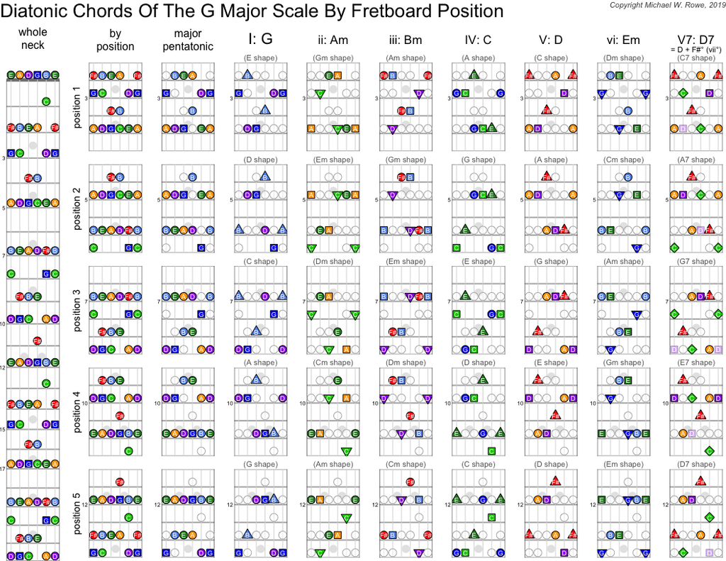

```r
scalePositionPlots("G", in.context=T, pdffile=NA, chorder="numeric")
```

Here is some code (**not** run) that will generate sets of these fretboard maps, each in a single *.pdf file with all keys. The three sets differ by how they order the chords within each key: numerically, by fourths or by fifths:

```r
# generate scale position plots for each tonic in a single file
for(chorder in c("numeric", "5ths", "4ths")){
   suffix <- ifelse(chorder%in%c("4ths", "5ths"), paste0(" by ", chorder), "")
   pdffile <-
      file.path(out.dir, paste0("major scale fretboards", suffix, ".pdf"))
   pdf(file=pdffile, width=11, height=8.5, paper="a4r", onefile=TRUE)
   for(key in c("F","C","G","D","A","E","B","F#","Db","Ab","Eb","Bb")){
      scalePositionPlots(key, in.context=T, pdffile=NA, chorder=chorder)
   }
   dev.off()
}
```

## parallelModePlots()

Parallel mode plots emphasize how the modes of a given tonic note relate to each other. They are arranged from the “brightest” mode, lydian, to the "darkest" mode, locrian, such that only a single note changes between each mode. The ionian mode (i.e. the major scale) is highlighted.

Also use horizontal orientation for these plots:

```r
# plot to the default device (not run)
dev.new(noRStudioGD = TRUE, width=11, height=8.5)
```

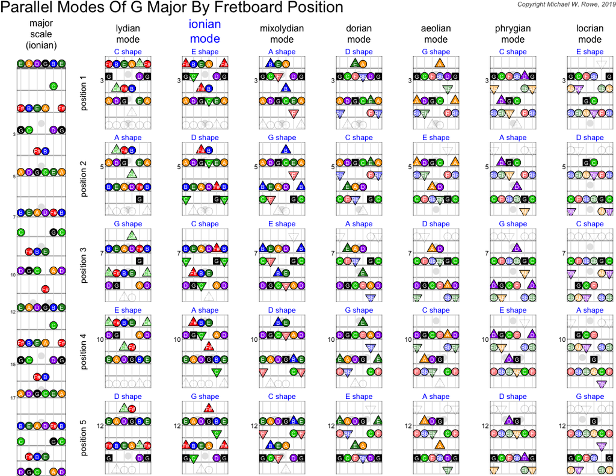

```r
# generate plots of the modes with G as their tonic note:
parallelModePlots("G", pdffile=NA)
```

Here is some code (**not** run) that will generate parallel scale fretboard maps in each key:

```r
# generate parallel mode plots for each tonic in a single file
pdf(file=file.path(out.dir, "parallel scale fretboards.pdf"),
    width=11, height=8.5, paper="a4r", onefile=TRUE)
for(key in c("F","C","G","D","A","E","B","F#","Db","Ab","Eb","Bb")){
   parallelModePlots(key, pdffile=NA)
}
dev.off()
```